# Markov Chain Monte Carlo

February 19, 2019

## Obligatory Disclosure

- Ben is an employee of Columbia University, which has received several research grants to develop Stan
- Ben is also a manager of GG Statistics LLC, which uses Stan for business purposes
- According to Columbia University [policy](https://research.columbia.edu/content/conflict-interest-and-research), any such employee who has any equity stake in, a title (such as officer or director) with, or is expected to earn at least \(\$5,000.00\) per year from a private company is required to disclose these facts in presentations

## Drawing from a Uniform Distribution

- Randomness can be harvested from physical sources, but it is expensive
- Modern Intel processors have a (possibly) [true random-number generator](https://en.wikipedia.org/wiki/RdRand)
- In practice, software emulates a true random-number generator for speed
- Let \(K = -1 + 2^{64} = 18,446,744,073,709,551,615\) be the largest unsigned integer that a 64-bit computer can represent. You can essentially draw uniformally from \(\Omega_U = \left[0,1\right)\) by
  1. Drawing \(\tilde{y}\) from \(\Omega_Y = \{0,1,\dots,K\}\) with each probability \(\frac{1.0}{K}\)
  2. Letting \(\tilde{u} = \frac{\tilde{y}}{1.0 + K}\), which casts to a double-precision denominator
- The CDF of the uniform distribution on \(\left(a,b\right)\) is \(F\left(\left.u\right|a,b\right) = \frac{u - a}{b - a}\) and the PDF is \(f\left(\left.u\right|a,b\right) = \frac{1}{b - a}\). Standard is a special case with \(a = 0\) and \(b = 1\).

## Drawing from an Exponential Distribution

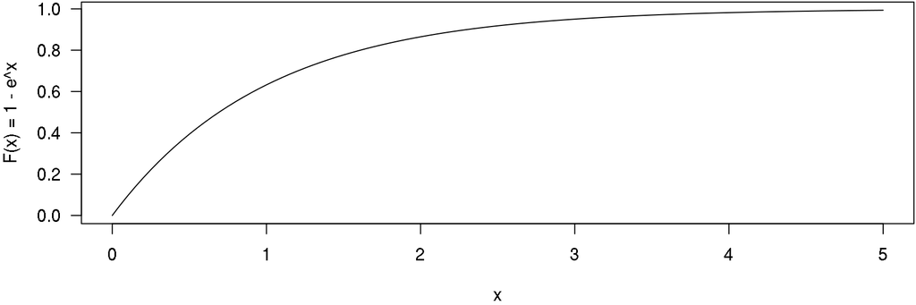

- To draw from this (standard exponential) distribution, you could
  1. Draw \(\tilde{u}\) from a standard uniform distribution
  2. Find the point on the curve with height \(\tilde{u}\)
  3. Drop to the horizontal axis at \(\tilde{x}\) to get a standard exponential realization
  4. Optionally scale \(\tilde{x}\) by a given \(\mu\) to make it non-standard

## Inverse CDF Sampling of Continuous RVs

- In principle, the previous implies an algorithm to draw from ANY univariate continuous distribution
- But to draw efficiently from it, it is best to work out (if possible) \(F^{-1}\left(u\right) = x\left(u\right)\), which is known as the inverse CDF from \(\left(0,1\right)\) to \(\Omega_X\)
- For example, if \(u\left(x\right) = 1 - e^x\), then \(x\left(u\right) = \ln\left(1-u\right) = F^{-1}\left(u\right)\)
- If \(U\) is distributed standard uniform and \(X = F^{-1}\left(U\right)\) what is the PDF of \(X\)?
- Since \(u = F\left(x\right)\) has a constant density of \(1\) and \(\frac{\partial}{\partial x}u\left(x\right) = \frac{\partial}{\partial x}F\left(x\right) = f\left(u\left(x\right)\right)\), the PDF of \(X\) is whatever \(f\left(x\right)\) is
- If \(F\left(x\right)\) does not have an explicit form, you may have to numerically solve for \(\tilde{x}\) such that \(F\left(\tilde{x}\right) = \tilde{u}\)

## Bivariate Normal Distribution

The PDF of the bivariate normal distribution over \(\Omega = \mathbb{R}^2\) is \[f\left(\left.x,y\right|\mu_X,\mu_Y,\sigma_X,\sigma_Y,\rho\right) = \\ \frac{1}{2\pi\sigma_X\sigma_Y\sqrt{1-\rho^2}}e^{-\frac{1}{2\left(1-\rho^2\right)} \left(\left(\frac{x - \mu_X}{\sigma_X}\right)^2 + \left(\frac{y - \mu_Y}{\sigma_Y}\right)^2 - 2\rho\frac{x - \mu_X}{\sigma_X}\frac{y - \mu_Y}{\sigma_Y}\right)} = \\ \frac{1}{\sigma_X\sqrt{2\pi}}e^{-\frac{1}{2}\left(\frac{x - \mu_X}{\sigma_X}\right)^2} \times \frac{1}{\color{blue}{\sigma}\sqrt{2\pi}}e^{-\frac{1}{2} \left(\frac{y - \color{red}{\left(\mu_y + \beta\left(x-\mu_X\right)\right)}} {\color{blue}{\sigma}}\right)^2},\] where \(X\) is MARGINALLY normal and \(\left.Y\right|X\) is CONDITIONALLY normal with expectation \(\color{red}{\mu_Y + \beta\left(x-\mu_X\right)}\) and standard deviation \(\color{blue}{\sigma = \sigma_Y\sqrt{1-\rho^2}}\), where \(\color{red}{\beta = \rho\frac{\sigma_Y}{\sigma_X}}\) is the OLS coefficient when \(Y\) is regressed on \(X\) and \(\sigma\) is the error standard deviation. We can thus draw \(\tilde{x}\) and then condition on it to draw \(\tilde{y}\).

## Drawing from the Bivariate Normal Distribution

```
functions { /* saved as binormal_rng.stan in R's working directory */
  matrix binormal_rng(int S, real mu_X, real mu_Y, real sigma_X, real sigma_Y, real rho) {
    matrix[S, 2] draws;
    real beta = rho * sigma_Y / sigma_X;          // calculate such constants once ...
    real sigma = sigma_Y * sqrt(1 - square(rho)); // ... before the loop begins
    for (s in 1:S) {
      real x = normal_rng(mu_X, sigma_X);
      real y = normal_rng(mu_Y + beta * (x - mu_X), sigma);
      draws[s, 1] = x; draws[s, 2] = y;
    }
    return draws;
  }
}
```

```r
rstan::expose_stan_functions("binormal_rng.stan")
S <- 1000; mu_X <- 0; mu_Y <- 0; sigma_X <- 1; sigma_Y <- 1; rho <- 0.75
indep <- replicate(26, colMeans(binormal_rng(S = 100, mu_X, mu_Y, sigma_X, sigma_Y, rho)))
rownames(indep) <- c("x", "y"); colnames(indep) <- letters
```

## Markov Processes

- A Markov process is a sequence of random variables with a particular dependence structure where the future is conditionally independent of the past given the present, but nothing is marginally independent of anything else
- An AR1 model is a linear Markov process
- Let \(X_s\) have conditional PDF \(f_s\left(\left.X_s\right|X_{s - 1}\right)\). Their joint PDF is \[f\left(X_0, X_1, \dots, X_{S - 1}, X_S\right) = f_0\left(X_0\right) \prod_{s = 1}^S f_s\left(\left.X_s\right|X_{s - 1}\right)\]
- Can we construct a Markov process such that the marginal distribution of \(X_S\) is a given target distribution as \(S\uparrow \infty\)?
- If so, they you can get a random draw — or a set of dependent draws — from the target distribution by letting that Markov process run for a long time
- Basic idea is that you can marginalize by going through a lot of conditionals

## Metropolis-Hastings Markov Chain Monte Carlo

- Suppose you want to draw from some distribution whose PDF is \(f\left(\left.\boldsymbol{\theta}\right|\dots\right)\) but do not have a customized algorithm to do so.
- Initialize \(\boldsymbol{\theta}\) to some value in \(\Theta\) and then repeat \(S\) times:
  1. Draw a proposal for \(\boldsymbol{\theta}\), say \(\boldsymbol{\theta}^\prime\), from a distribution whose PDF is \(q\left(\left.\boldsymbol{\theta}^\prime\right|\dots\right)\)
  2. Let \(\alpha^\ast = \mathrm{min}\{1,\frac{f\left(\left.\boldsymbol{\theta}^\prime\right|\dots\right)} {f\left(\left.\boldsymbol{\theta}\right|\dots\right)} \frac{q\left(\left.\boldsymbol{\theta}\right|\dots\right)} {q\left(\left.\boldsymbol{\theta}^\prime\right|\dots\right)}\}\). N.B.: Constants cancel so not needed!
  3. If \(\alpha^\ast\) is greater than a standard uniform variate, set \(\boldsymbol{\theta} = \boldsymbol{\theta}^\prime\)
  4. Store \(\boldsymbol{\theta}\) as the \(s\)-th draw
- The \(S\) draws of \(\boldsymbol{\theta}\) have PDF \(f\left(\left.\boldsymbol{\theta}\right|\dots\right)\) but are NOT independent
- If \(\frac{q\left(\left.\boldsymbol{\theta}\right|\dots\right)} {q\left(\left.\boldsymbol{\theta}^\prime\right|\dots\right)} = 1\), called Metropolis MCMC

## Metropolis Sampling from a Bivariate Normal

```
functions { /* saved as Metropolis_rng.stan in R's working directory */

  real binormal_lpdf(row_vector xy, real mu_X, real mu_Y, real sigma_X, real sigma_Y, real rho) {
    real beta = rho * sigma_Y / sigma_X; real sigma = sigma_Y * sqrt(1 - square(rho));
    if (is_inf(xy[1]) || is_inf(xy[2])) return negative_infinity();
    return normal_lpdf(xy[1] | mu_X, sigma_X) + // normal_lpdf is the logarithm of the normal PDF
           normal_lpdf(xy[2] | mu_Y + beta * (xy[1] - mu_X), sigma);
  }

  matrix Metropolis_rng(int S, real half_width, real mu_X, real mu_Y, real sigma_X, real sigma_Y, real rho) {
    matrix[S, 2] draws; real x = 0; real y = 0; // must initialize these before the loop so they persist
    for (s in 1:S) {
      real x_ = uniform_rng(x - half_width, x + half_width);
      real y_ = uniform_rng(y - half_width, y + half_width); // vvv can call previously-declared functions
      real alpha_star = exp(binormal_lpdf([x_, y_] | mu_X, mu_Y, sigma_X, sigma_Y, rho) -
                            binormal_lpdf([x , y ] | mu_X, mu_Y, sigma_X, sigma_Y, rho));
      if (alpha_star > uniform_rng(0, 1)) { // Q([x, y]) / Q[x_, y_] = 1 in this case
        x = x_; y = y_;
      } // otherwise leave x and y the same as they were on iteration s - 1
      draws[s, 1] = x;  draws[s, 2] = y;
    } // x_, y_, and alpha_star all get deleted here but x and y do not
    return draws;
  }
}
```

```r
rstan::expose_stan_functions("Metropolis_rng.stan")
```

## Efficiency in Estimating \(\mathbb{E}X\) & \(\mathbb{E}Y\) w/ Metropolis

```r
means <- replicate(26, colMeans(Metropolis_rng(S, 2.75, mu_X, mu_Y, sigma_X, sigma_Y, rho)))
rownames(means) <- c("x", "y"); colnames(means) <- LETTERS; round(means, digits = 3)
```

```
##       A      B      C      D     E      F      G      H     I      J      K      L     M
## x 0.142 -0.147 -0.095 -0.072 0.082 -0.050 -0.194 -0.175 0.005  0.076 -0.130 -0.033 0.057
## y 0.167 -0.122 -0.013 -0.113 0.074 -0.001 -0.215 -0.163 0.014 -0.003  0.006 -0.013 0.036
##        N      O      P      Q     R      S     T      U      V     W      X      Y     Z
## x -0.074 -0.021 -0.057 -0.032 0.031  0.037 0.081 -0.034 -0.087 0.032 -0.113 -0.059 0.155
## y -0.043 -0.081 -0.113  0.050 0.076 -0.012 0.085 -0.088 -0.124 0.014 -0.003 -0.045 0.095
```

```r
round(indep, digits = 3) # note S was 100, rather than 1000
```

```
##       a      b      c     d     e      f      g      h      i      j      k      l     m
## x 0.146 -0.146 -0.148 0.106 0.059  0.010 -0.029 -0.135  0.033 -0.107 -0.115  0.029 0.034
## y 0.111 -0.053 -0.155 0.045 0.096 -0.026 -0.081 -0.054 -0.001 -0.083 -0.119 -0.027 0.115
##       n      o      p      q      r      s      t     u      v     w      x      y     z
## x 0.065 -0.067 -0.005 -0.135 -0.130 -0.325 -0.130 0.093 -0.117 0.248  0.023 -0.012 0.124
## y 0.013 -0.125  0.035 -0.104 -0.169 -0.180 -0.188 0.136 -0.076 0.145 -0.031  0.025 0.074
```

## Autocorrelation of Metropolis MCMC

```r
xy <- Metropolis_rng(S, 2.75, mu_X, mu_Y, sigma_X, sigma_Y, rho); nrow(unique(xy))
```

```
## [1] 236
```

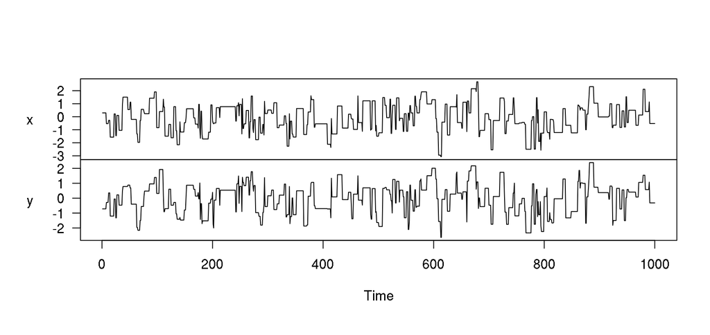

```r
colnames(xy) <- c("x", "y"); plot(as.ts(xy), main = "")
```

## Effective Sample Size of Markov Chain Output

- If a Markov Chain mixes fast enough for the MCMC CLT to hold, then
  - The Effective Sample Size is \(n_{eff} = \frac{S}{1 + 2\sum_{k=1}^\infty \rho_k}\), where \(\rho_k\) is the ex ante autocorrelation between two draws that are \(k\) iterations apart
  - The MCMC Standard Error of the mean of the \(S\) draws is \(\frac{\sigma}{\sqrt{n_{eff}}}\) where \(\sigma\) is the true posterio standard deviation
- If \(\rho_k = 0 \forall k\), then \(n_{eff} = S\) and the MCMC-SE is \(\frac{\sigma}{\sqrt{S}}\), so the Effective Sample Size is the number of INDEPENDENT draws that would be expected to estimate the posterior mean of some function with the same accuracy as the \(S\) DEPENDENT draws that you have from the posterior distribution
- Both have to be estimated and unfortunately, the estimator is not that reliable when the true Effective Sample Size is low (~5% of \(S\))
- For this Metropolis sampler, \(n_{eff}\) is estimated to be \(\approx 100\) for both margins

## Gibbs Samplers

- Metropolis-Hastings where \(q\left(\left.\theta_k^\prime\right|\dots\right) = f\left(\left.\theta_k^\prime\right|\boldsymbol{\theta}_{-k}\dots\right)\) and \(\boldsymbol{\theta}_{-k}\) consists of all elements of \(\boldsymbol{\theta}\) except the \(k\)-th
- \(\alpha^\ast = \mathrm{min}\{1,\frac{f\left(\left.\boldsymbol{\theta}^\prime\right|\dots\right)} {f\left(\left.\boldsymbol{\theta}\right|\dots\right)} \frac{f\left(\left.\theta_k\right|\boldsymbol{\theta}_{-k}\dots\right)} {f\left(\left.\theta_k^\prime\right|\boldsymbol{\theta}_{-k}\dots\right)}\} = \mathrm{min}\{1,\frac{f\left(\left.\theta_k^\prime\right|\boldsymbol{\theta}_{-k}\dots\right) f\left(\left.\boldsymbol{\theta}_{-k}\right|\dots\right)} {f\left(\left.\theta_k\right|\boldsymbol{\theta}_{-k}\dots\right) f\left(\left.\boldsymbol{\theta}_{-k}\right|\dots\right)} \frac{f\left(\left.\theta_k\right|\boldsymbol{\theta}_{-k}\dots\right)} {f\left(\left.\theta_k^\prime\right|\boldsymbol{\theta}_{-k}\dots\right)}\} = 1\) so \(\theta_k^\prime\) is ALWAYS accepted by construction. But \(\theta_k^\prime\) may be very close to \(\theta_k\) when the variance of the “full-conditional” distribution of \(\theta_k^\prime\) given \(\boldsymbol{\theta}_{-k}\) is small
- Can loop over \(k\) to draw sequentially from each full-conditional distribution
- Presumes that there is an algorithm to draw from the full-conditional distribution for each \(k\). Most times have to fall back to something else.

## Gibbs Sampling from the Bivariate Normal

```
functions { /* saved as Gibbs_rng.stan in R's working directory */
  matrix Gibbs_rng(int S, real mu_X, real mu_Y, real sigma_X, real sigma_Y, real rho) {
    matrix[S, 2] draws; real x = 0; // must initialize before loop so that it persists
    real beta = rho * sigma_Y / sigma_X;
    real lambda = rho * sigma_X / sigma_Y;
    real sqrt1mrho2 = sqrt(1 - square(rho));
    real sigma_YX = sigma_Y * sqrt1mrho2;
    real sigma_XY = sigma_X * sqrt1mrho2; // this is smaller than in binormal_rng.stan !
    for (s in 1:S) {
      real y = normal_rng(mu_Y + beta * (x - mu_X), sigma_YX); // y needs a persistent x
      x = normal_rng(mu_X + lambda * (y - mu_Y), sigma_XY); // overwritten not redeclared
      draws[s, 1] = x; draws[s, 2] = y;
    } // y gets deleted here but x does not
    return draws;
  }
}
```

```r
rstan::expose_stan_functions("Gibbs_rng.stan")
```

## Autocorrelation of Gibbs Sampling: \(n_{eff} \approx 300\)

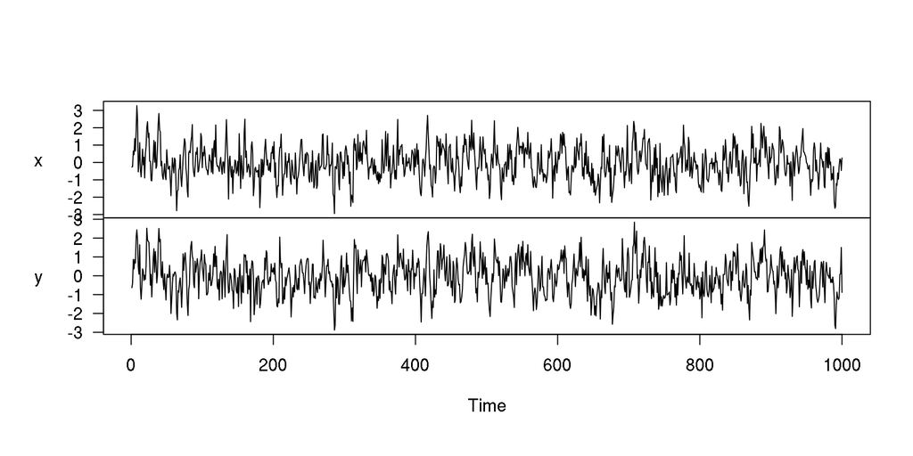

```r
xy <- Gibbs_rng(S, mu_X, mu_Y, sigma_X, sigma_Y, rho)
colnames(xy) <- c("x", "y")
plot(as.ts(xy), main = "")
```

## What the BUGS Software Family Essentially Does

```r
library(Runuran) # defines ur() which draws from the approximate ICDF via pinv.new()
BUGSish <- function(log_kernel, # function of theta outputting posterior log-kernel
                    theta,      # starting values for all the parameters
                    ...,        # additional arguments passed to log_kernel
                    LB = rep(-Inf, K), UB = rep(Inf, K), # optional bounds on theta
                    S = 1000) { # number of posterior draws to obtain
  K <- length(theta); draws <- matrix(NA, nrow = S, ncol = K)
  for(s in 1:S) { # these loops are slow, as is approximating the ICDF | theta[-k]
    for (k in 1:K) {
      full_conditional <- function(theta_k)
        return(log_kernel(c(head(theta, k - 1), theta_k, tail(theta, K - k)), ...))
      theta[k] <- ur(pinv.new(full_conditional, lb = LB[k], ub = UB[k], islog = TRUE,
                              uresolution = 1e-8, smooth = TRUE, center = theta[k]))
    }
    draws[s, ] <- theta
  }
  return(draws)
}
```

## Gibbs Sampling a la BUGS: \(n_{eff} \approx 200\)

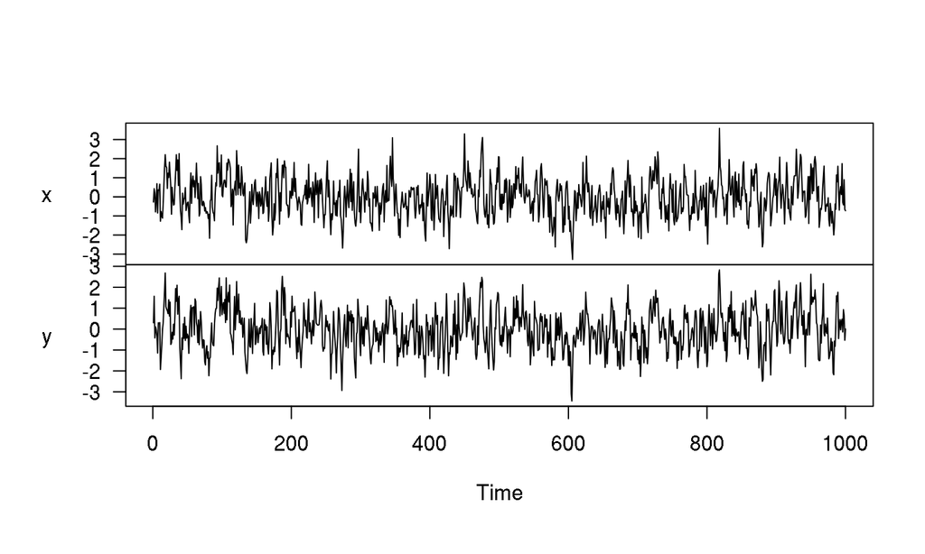

```r
xy <- BUGSish(binormal_lpdf, theta = c(0,0),
              mu_X, mu_Y, sigma_X, sigma_Y, rho)
colnames(xy) <- c("x", "y")
plot(as.ts(xy), main = "")
```